# SHRS Market Analysis — 2024 Participation Rates (Table 3.3)

SHRS MQE Capstone Team

2026-02-14

```r
library(tidyverse); library(scales); library(knitr); library(kableExtra)
```

# 0 — Configuration

```r
VINTAGE <- "2024"
YR1 <- 2004; YR2 <- 2014; YR3 <- 2024; YR4 <- 2034
PROJ_LABEL <- paste0(YR3, "-", YR4)

CSV_PATH <- file.path(path.expand("~"), "Documents", "SHRS_Analysis",
                       "market_analysis", "v3data", "projections_csv",
                       "labor_force_csv", VINTAGE,
                       paste0("labor-force_", VINTAGE, " - Table 3.3.csv"))

signal_colors <- c("Green"="#27ae60","Yellow"="#f39c12","Red"="#e74c3c")
```

# 1 — Load & Clean

Table 3.3: Labor force participation rates by demographic group — the share of each population segment that is working or actively seeking work.

```r
raw <- read_csv(CSV_PATH, show_col_types = FALSE)

# 11 columns: Group + 4 rates + 3 rate changes + 3 CAGRs
names(raw) <- c("group",
                "rate_yr1","rate_yr2","rate_yr3","rate_yr4",
                "rate_chg_12","rate_chg_23","rate_chg_34",
                "cagr_12","cagr_23","cagr_34")

clean_num <- function(x) {
  x <- str_remove_all(as.character(x), ",")
  x[x %in% c("—","–","-","NA","")] <- NA
  suppressWarnings(as.numeric(x))
}

raw <- raw |>
  mutate(group = str_trim(group)) |>
  filter(group != "", !is.na(group)) |>
  mutate(across(-group, clean_num))
```

```r
cat(paste0("**Vintage:** ",VINTAGE," | **Rows:** ",nrow(raw),"\n"))
```

**Vintage:** 2024 | **Rows:** 52

# 2 — Overall Participation Rate Trend

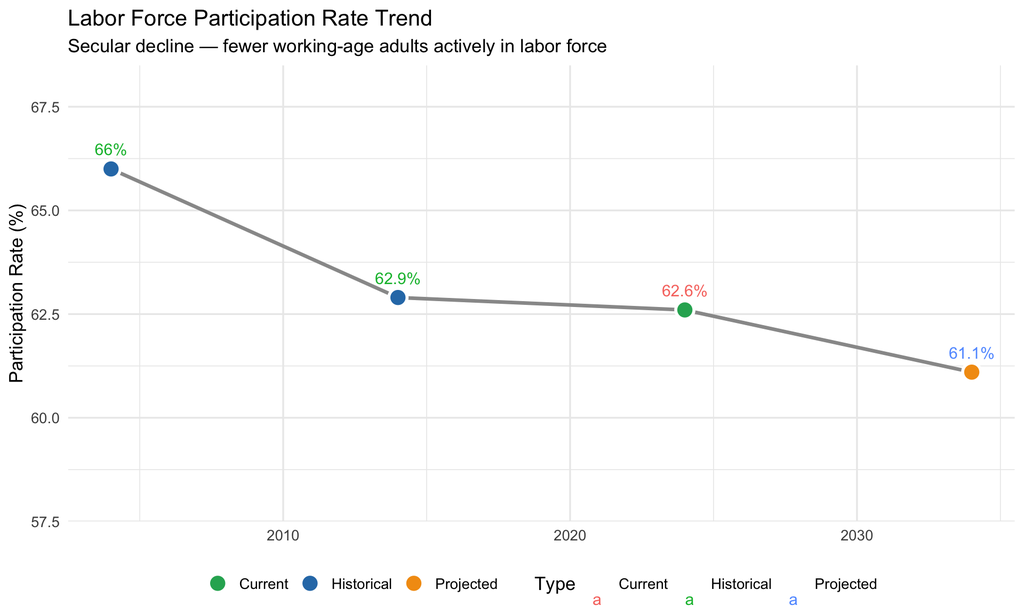

```r
total <- raw |> filter(str_detect(group, "^Total"))

rate_trend <- tibble(
  Year = c(YR1, YR2, YR3, YR4),
  Rate = c(total$rate_yr1, total$rate_yr2, total$rate_yr3, total$rate_yr4),
  Type = c("Historical","Historical","Current","Projected")
)

rate_trend |>
  ggplot(aes(x=Year, y=Rate, color=Type)) +
  geom_line(linewidth=1.2, color="gray60") +
  geom_point(aes(fill=Type), shape=21, size=5, color="white", stroke=1.5) +
  geom_text(aes(label=paste0(Rate,"%")), vjust=-1.2, size=4) +
  scale_fill_manual(values=c("Historical"="#2c7bb6","Current"="#27ae60","Projected"="#f39c12")) +
  scale_y_continuous(limits=c(58,68)) +
  labs(title="Labor Force Participation Rate Trend",
       subtitle="Secular decline — fewer working-age adults actively in labor force",
       x=NULL, y="Participation Rate (%)", fill=NULL) +
  theme_minimal(base_size=13) + theme(legend.position="bottom")
```

```r
# Store benchmarks
lfpr_current   <- total$rate_yr3
lfpr_projected <- total$rate_yr4
lfpr_change    <- total$rate_chg_34
```

```r
tibble(
  Metric = c(paste0("LFPR ",YR1), paste0("LFPR ",YR2), paste0("LFPR ",YR3),
             paste0("LFPR ",YR4," (projected)"),
             paste0("Change ",YR1,"-",YR2," (pp)"), paste0("Change ",YR2,"-",YR3," (pp)"),
             paste0("Change ",YR3,"-",YR4," (pp)")),
  Value = c(total$rate_yr1, total$rate_yr2, total$rate_yr3, total$rate_yr4,
            total$rate_chg_12, total$rate_chg_23, total$rate_chg_34)
) |>
  kable(digits=1, caption="Overall LFPR Summary") |>
  kable_styling(bootstrap_options=c("striped","hover"), full_width=FALSE)
```

Overall LFPR Summary

| Metric | Value |
| --- | --- |
| LFPR 2004 | 66.0 |
| LFPR 2014 | 62.9 |
| LFPR 2024 | 62.6 |
| LFPR 2034 (projected) | 61.1 |
| Change 2004-2014 (pp) | -3.1 |
| Change 2014-2024 (pp) | -0.3 |
| Change 2024-2034 (pp) | -1.5 |

# 3 — Participation by Gender

```r
gender <- raw |> filter(str_detect(group, "^Men, 16|^Women, 16"))

gender |>
  select(Group=group, !!paste0("Rate ",YR3):=rate_yr3, !!paste0("Rate ",YR4):=rate_yr4,
         !!paste0("Change (pp)"):=rate_chg_34) |>
  kable(digits=1, caption="LFPR by Gender") |>
  kable_styling(bootstrap_options=c("striped","hover"), full_width=FALSE)
```

LFPR by Gender

| Group | Rate 2024 | Rate 2034 | Change (pp) |
| --- | --- | --- | --- |
| Men, 16 years and older | 68.0 | 65.8 | -2.2 |
| Women, 16 years and older | 57.5 | 56.7 | -0.8 |

# 4 — Participation by Age

```r
age <- raw |>
  filter(str_detect(group, "^\\s*\\d+\\s+to\\s+\\d+|^\\s*55 and|^\\s*65 and|^\\s*75 and")) |>
  mutate(group = str_trim(group))

if (nrow(age) > 0) {
  age |>
    ggplot(aes(x=reorder(group, rate_yr3), y=rate_yr3)) +
    geom_segment(aes(xend=group, y=rate_yr4, yend=rate_yr3),
                 color="gray70", linewidth=1) +
    geom_point(aes(color="Current"), size=4) +
    geom_point(aes(y=rate_yr4, color="Projected"), size=4) +
    coord_flip() +
    scale_color_manual(values=c("Current"="#2c7bb6","Projected"="#f39c12")) +
    labs(title=paste0("LFPR by Age Group: ",YR3," vs ",YR4," (Projected)"),
         subtitle="Dot = current rate; arrow = projected direction",
         x=NULL, y="Participation Rate (%)", color=NULL) +
    theme_minimal(base_size=12) + theme(legend.position="bottom")

  age |>
    select(Age=group, !!paste0("Rate ",YR3):=rate_yr3,
           !!paste0("Rate ",YR4):=rate_yr4, `Change (pp)`=rate_chg_34) |>
    kable(digits=1, caption="LFPR by Age Group") |>
    kable_styling(bootstrap_options=c("striped","hover"), full_width=FALSE)
}
```

LFPR by Age Group

| Age | Rate 2024 | Rate 2034 | Change (pp) |
| --- | --- | --- | --- |
| 16 to 24 | 55.9 | 53.6 | -2.3 |
| 16 to 19 | 36.9 | 34.6 | -2.3 |
| 20 to 24 | 71.5 | 69.1 | -2.4 |
| 25 to 54 | 83.6 | 82.8 | -0.8 |
| 25 to 34 | 83.7 | 82.8 | -0.8 |
| 35 to 44 | 84.7 | 83.9 | -0.8 |
| 45 to 54 | 82.3 | 81.6 | -0.7 |
| 55 and older | 38.4 | 36.9 | -1.6 |
| 55 to 64 | 65.9 | 68.6 | 2.7 |
| 65 to 74 | 27.1 | 29.6 | 2.5 |
| 75 and older | 8.6 | 10.2 | 1.5 |
| 16 to 24 | 56.4 | 52.9 | -3.4 |
| 16 to 19 | 36.4 | 34.1 | -2.2 |
| 20 to 24 | 73.1 | 68.4 | -4.6 |
| 25 to 54 | 89.3 | 87.8 | -1.5 |
| 25 to 34 | 89.3 | 86.8 | -2.5 |
| 35 to 44 | 90.7 | 89.4 | -1.2 |
| 45 to 54 | 87.9 | 87.2 | -0.7 |
| 55 and older | 43.9 | 41.6 | -2.3 |
| 55 to 64 | 71.6 | 73.9 | 2.2 |
| 65 to 74 | 31.2 | 33.1 | 1.9 |
| 75 and older | 11.3 | 12.8 | 1.4 |
| 16 to 24 | 55.4 | 54.3 | -1.0 |
| 16 to 19 | 37.4 | 35.1 | -2.3 |
| 20 to 24 | 69.9 | 69.8 | -0.1 |
| 25 to 54 | 77.9 | 77.8 | -0.1 |
| 25 to 34 | 78.1 | 78.9 | 0.8 |
| 35 to 44 | 78.7 | 78.4 | -0.3 |
| 45 to 54 | 76.8 | 76.1 | -0.7 |
| 55 and older | 33.6 | 32.7 | -0.9 |
| 55 to 64 | 60.4 | 63.6 | 3.2 |
| 65 to 74 | 23.5 | 26.5 | 3.0 |
| 75 and older | 6.5 | 8.1 | 1.5 |

# 5 — Participation by Race/Ethnicity

```r
race <- raw |>
  filter(str_detect(group, "^White,|^Black,|^Asian,|^Hispanic origin,"))

if (nrow(race) > 0) {
  race |>
    select(Group=group, !!paste0("Rate ",YR3):=rate_yr3,
           !!paste0("Rate ",YR4):=rate_yr4, `Change (pp)`=rate_chg_34) |>
    kable(digits=1, caption="LFPR by Race/Ethnicity") |>
    kable_styling(bootstrap_options=c("striped","hover"), full_width=FALSE)
}
```

LFPR by Race/Ethnicity

| Group | Rate 2024 | Rate 2034 | Change (pp) |
| --- | --- | --- | --- |
| White, 16 years and older | 62.2 | 60.3 | -1.9 |
| Black, 16 years and older | 63.0 | 62.2 | -0.8 |
| Hispanic origin, 16 years and older | 67.2 | 66.5 | -0.7 |

# 6 — Healthcare Workforce Implications

```r
cat("### Implications for SHRS Programs\n\n")
```

### Implications for SHRS Programs

```r
cat(paste0("- <span style='color:#2c7bb6;'>**Declining LFPR:**</span> Overall rate falling from ",
           lfpr_current, "% to ", lfpr_projected, "% (", lfpr_change,
           " pp) — fewer workers available per capita\n"))
```

- **Declining LFPR:** Overall rate falling from 62.6% to 61.1% (-1.5 pp) — fewer workers available per capita

```r
cat(paste0("- <span style='color:#2c7bb6;'>**Aging-driven decline:**</span> ",
           "Older cohorts have lower participation rates; as they grow as ",
           "a share of the population, overall LFPR falls\n"))
```

- **Aging-driven decline:** Older cohorts have lower participation rates; as they grow as a share of the population, overall LFPR falls

```r
cat(paste0("- <span style='color:#2c7bb6;'>**Healthcare demand paradox:**</span> ",
           "The same aging that shrinks the labor supply *increases* demand for ",
           "rehabilitation, therapy, and health services — creating favorable ",
           "conditions for SHRS graduates\n"))
```

- **Healthcare demand paradox:** The same aging that shrinks the labor supply *increases* demand for rehabilitation, therapy, and health services — creating favorable conditions for SHRS graduates

```r
cat(paste0("- <span style='color:#2c7bb6;'>**Recruitment signal:**</span> ",
           "Tighter labor markets mean SHRS programs should emphasize strong ",
           "employment outcomes and competitive wages in recruitment materials\n"))
```

- **Recruitment signal:** Tighter labor markets mean SHRS programs should emphasize strong employment outcomes and competitive wages in recruitment materials

# 7 — Stored Outputs

```r
lf_t33_2024_raw       <- raw
lf_t33_2024_total     <- total
lf_t33_2024_gender    <- gender
lf_t33_2024_age       <- if(exists("age")) age else NULL
lf_t33_2024_race      <- if(exists("race")) race else NULL
lf_t33_2024_benchmarks <- list(
  lfpr_current = lfpr_current, lfpr_projected = lfpr_projected,
  lfpr_change_pp = lfpr_change, yr3 = YR3, yr4 = YR4
)
```

```r
cat("| Variable | Description |\n|---|---|\n")
```

| Variable | Description |
| --- | --- |

```r
cat(paste0("| `lf_t33_2024_raw` | Full T3.3 data (",nrow(raw)," rows) |\n"))
```

`lf_t33_2024_raw` | Full T3.3 data (52 rows) |

```r
cat("| `lf_t33_2024_total` | Total LFPR row |\n")
```

`lf_t33_2024_total` | Total LFPR row |

```r
cat("| `lf_t33_2024_gender` | Gender breakdown |\n")
```

`lf_t33_2024_gender` | Gender breakdown |

```r
cat("| `lf_t33_2024_age` | Age group rates |\n")
```

`lf_t33_2024_age` | Age group rates |

```r
cat("| `lf_t33_2024_benchmarks` | Key LFPR benchmarks (list) |\n")
```

`lf_t33_2024_benchmarks` | Key LFPR benchmarks (list) |

**Source:** BLS Table 3.3, 2024 vintage. Projection: 2024–2034.